# Experiment of DriveML R package - Big Data set

Dayanand, Sayan, Ravi, Kiran R

16/06/2021

```r
library(DriveML)    ## automl package
library(data.table) ## data wrangling package
library(caret)      ## ML wrapper package
library(mlr)        ## ML wrapper package
library(h2o)        ## automl package
library(OneR)       ## automl package
library(Metrics)    ## auc function
library(autoxgboost)## automl package
```

## Rain in Australia

data source : **https://www.kaggle.com/jsphyg/weather-dataset-rattle-package**

#### Content

`This dataset contains about 10 years of daily weather observations from many locations across Australia.

RainTomorrow is the target variable to predict. It means – did it rain the next day, Yes or No? This column is Yes if the rain for that day was 1mm or more.`

##### Problem Statement

Predict next-day rain by training classification models on the target variable RainTomorrow

###### Source & Acknowledgements

Observations were drawn from numerous weather stations. The daily observations are available from **http://www.bom.gov.au/climate/data.** An example of latest weather observations in Canberra: **http://www.bom.gov.au/climate/dwo/IDCJDW2801.latest.shtml**

Definitions adapted from **http://www.bom.gov.au/climate/dwo/IDCJDW0000.shtml** Data source: **http://www.bom.gov.au/climate/dwo/ and http://www.bom.gov.au/climate/data.**

Copyright Commonwealth of Australia 2010, Bureau of Meteorology.

# DriveML Experiment

```r
data_path = "C:/backup/R packages/DriveML_Experiments/big_data - weatherAUS"
weather_data <- fread(paste0(data_path, "\\","weatherAUS.csv"), sep = ",",header = TRUE)

##Recode target variable
weather_data[, RainTomorrow:= ifelse(RainTomorrow=='Yes',1,0)]
weather_data[, RainTomorrow:= ifelse(is.na(RainTomorrow),0,RainTomorrow)]
table(weather_data$RainTomorrow)
```

```
##
##      0      1
## 113583  31877
```

#### Split sample to test the model accuaracy with other open source R package

```r
set.seed(12345)
train.index <- createDataPartition(weather_data$RainTomorrow, p = .8, list = FALSE)
```

#### DriveML step 1 - Missing variable treatment

```r
marobj <- autoMAR (weather_data, aucv = 0.9, strataname = NULL, stratasize = NULL, mar_method="glm")
marobj$auc_features
```

#### DriveML step 2 - Auto Dataprep

```r
## Type of missing imputation
myimpute <- list(classes=list(factor = imputeMode(),
                              integer = imputeMean(),
                              numeric = imputeMedian(),
                              character = imputeMode()))

## AutoDataprep
traindata <- autoDataprep(weather_data, target = "RainTomorrow",
                          auto_mar = TRUE,
                          mar_object=marobj,
                          missimpute = myimpute,
                          dummyvar = TRUE,
                          aucv = 0.002, corr = 0.999,
                          outlier_flag = TRUE,
                          char_var_limit = 150,
                          interaction_var = TRUE,
                          frequent_var = TRUE,
                          #uid = 'ID',
                          verbose =TRUE)
```

```
## autoDataprep < MAR variable computation.... >
## autoDataprep < missing imputation.... >
## autoDataprep < Outlier treatment based on Tukey method....>
## autoDataprep < Frequent transformer....>
## autoDataprep < Interactions transformer....>
## autoDataprep < Categorical variable - one hot encoding....>
## autoDataprep < variable reduction - zero variance method.... >
## autoDataprep < variable selection - pearson correlation method.... >
## autoDataprep < variable selection - AUC method.... >
```

```r
master_data <- traindata$master_data
sele_var <- traindata$var_list$mydata_var
train_data <- master_data[sele_var]

### Train and valid data
train_d <- train_data[train.index,]
valid_d <- train_data[-train.index,]
```

#### DriveML step 3 - Model development

```r
mymodel_rain <- autoMLmodel( train = train_d,
                           test = valid_d,
                           target = 'RainTomorrow',
                           tuneIters = 10,
                           tuneType = "random",
                           models = "all",
                           varImp = 10,
                           liftGroup = 50,
                           maxObs = 5000,
                           #uid = 'ID',
                           htmlreport = FALSE,
                           pdp = TRUE,
                           verbose = TRUE,
                           seed = 42)

save(mymodel_rain, file="big_data_mymodel.rdata")
```

#### DriveML Results

**Model results**

```r
results <- mymodel_rain$results
kableExtra::kable(results)
```

|  | Model | Fitting time | Scoring time | Train AUC | Test AUC | Accuracy | Precision | Recall | F1_score |
| --- | --- | --- | --- | --- | --- | --- | --- | --- | --- |
| 5 | xgboost | 2.763 mins | 2.311 secs | 0.956 | 0.892 | 0.861 | 0.748 | 0.540 | 0.627 |
| 4 | ranger | 11.19 mins | 1.535 mins | 1.000 | 0.880 | 0.856 | 0.756 | 0.496 | 0.599 |
| 3 | randomForest | 27.422 mins | 17.544 secs | 1.000 | 0.879 | 0.855 | 0.761 | 0.487 | 0.594 |
| 2 | logreg | 27.214 secs | 0.441 secs | 0.869 | 0.871 | 0.849 | 0.717 | 0.506 | 0.593 |
| 1 | glmnet | 33.127 mins | 0.607 secs | 0.857 | 0.858 | 0.845 | 0.734 | 0.445 | 0.554 |
| 6 | rpart | 30.951 secs | 1.052 secs | 0.779 | 0.778 | 0.840 | 0.728 | 0.421 | 0.534 |

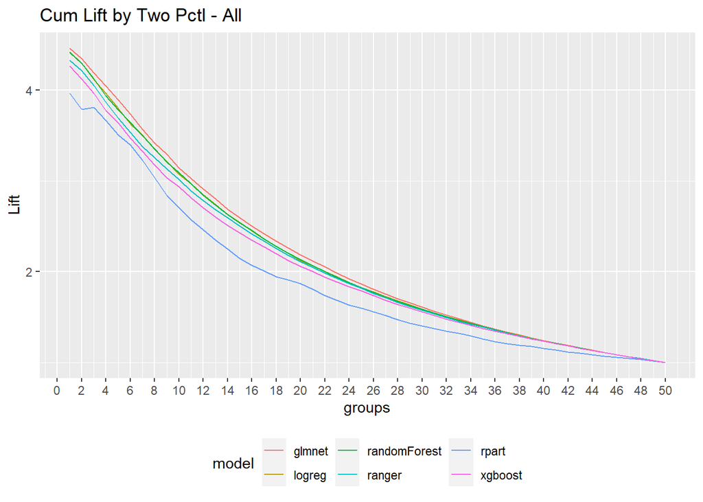

```r
## Variable Lift
mymodel_rain$modelexp$Lift_plot
```

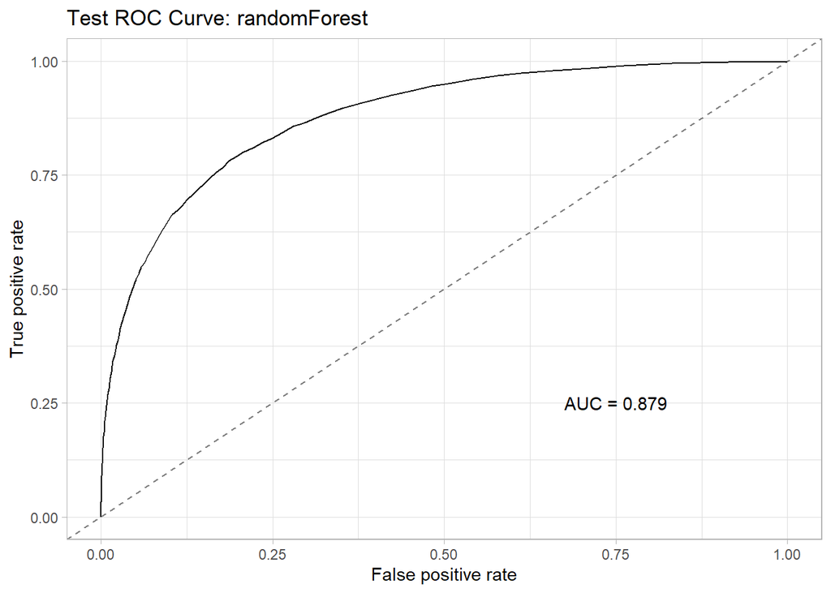

```r
### Random Forest Model validation ROC
mymodel_rain$trainedModels$randomForest$modelPlots$TestROC
```

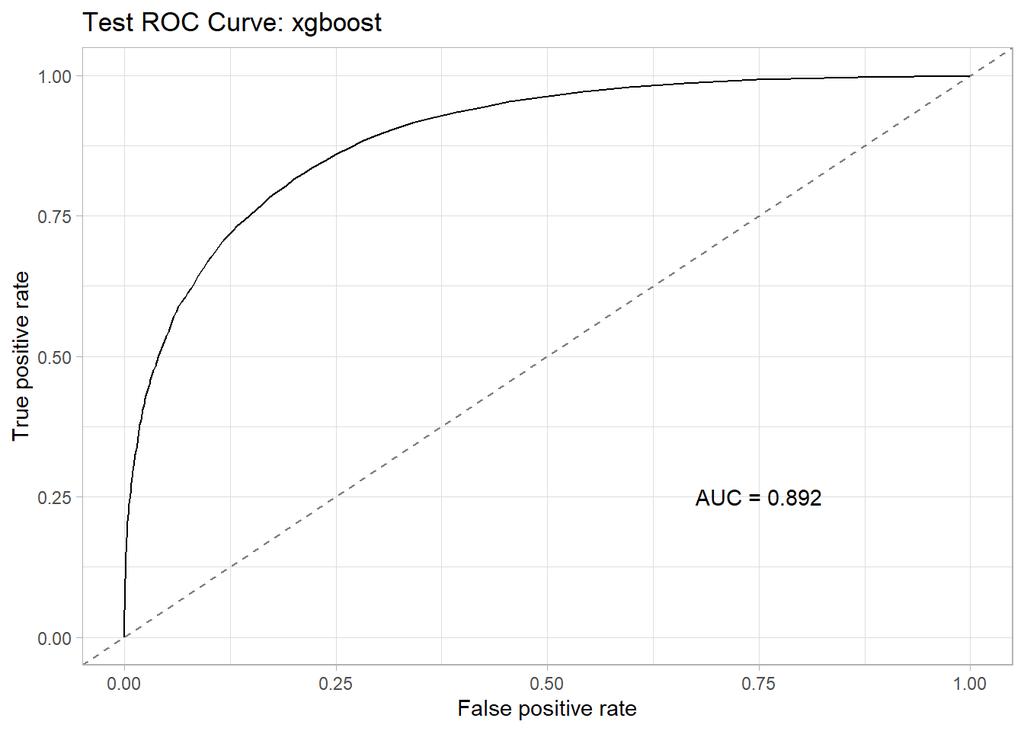

```r
### XGBoost Model validation ROC
mymodel_rain$trainedModels$xgboost$modelPlots$TestROC
```

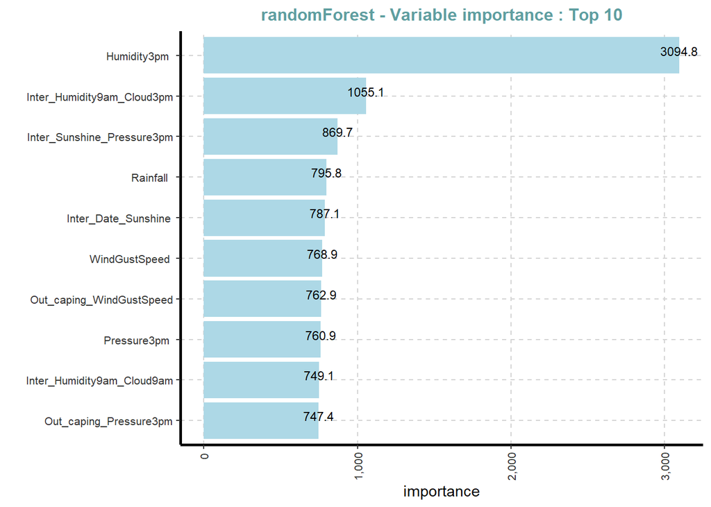

```r
### Random Forest Model Variable Importance
mymodel_rain$trainedModels$randomForest$modelPlots$VarImp
```

# Best ML model comparison with other R packages

### 1. DriveML

available on CRAN and git

selected best model from driveml outcome

```r
time <- Sys.time()
marobj <- autoMAR (weather_data, aucv = 0.9, strataname = NULL, stratasize = NULL, mar_method="glm")
## Type of missing imputation
myimpute <- list(classes=list(factor = imputeMode(),
                              integer = imputeMean(),
                              numeric = imputeMedian(),
                              character = imputeMode()))

## AutoDataprep
traindata <- autoDataprep(weather_data, target = "RainTomorrow",
                          auto_mar = TRUE,
                          mar_object=marobj,
                          missimpute = myimpute,
                          dummyvar = TRUE,
                          aucv = 0.002, corr = 0.999,
                          outlier_flag = TRUE,
                          char_var_limit = 150,
                          interaction_var = TRUE,
                          frequent_var = TRUE,
                          verbose =TRUE)
```

```
## autoDataprep < MAR variable computation.... >
## autoDataprep < missing imputation.... >
## autoDataprep < Outlier treatment based on Tukey method....>
## autoDataprep < Frequent transformer....>
## autoDataprep < Interactions transformer....>
## autoDataprep < Categorical variable - one hot encoding....>
## autoDataprep < variable reduction - zero variance method.... >
## autoDataprep < variable selection - pearson correlation method.... >
## autoDataprep < variable selection - AUC method.... >
```

```r
master_data <- traindata$master_data
sele_var <- traindata$var_list$mydata_var
train_data <- master_data[sele_var]

### Train and valid data
train_d <- train_data[train.index,]
valid_d <- train_data[-train.index,]

driveml_bigdata <- autoMLmodel( train = train_d,
                             test = valid_d,
                             target = 'RainTomorrow',
                             models = "xgboost",
                             maxObs = 5000,
                             verbose = TRUE,
                             seed = 42)
```

```
## xgboost Model tuning started....
## autoMLmodel < All features xgboost tuned and trained >
```

```r
dtime <- round(difftime(Sys.time(), time, units='secs'),3)
```

```r
bestroc <- round(driveml_bigdata$results$`Test AUC`,3)

comparision_metric <- matrix(data=NA, nrow=4, ncol=8)
colnames(comparision_metric) <- c("r_package_name","dataset_name","attributes","missing","Train_instances","Test_instances", "time_taken_min", "test_auc")

comparision_metric[1,"dataset_name"] <- "Big data"
comparision_metric[1,"r_package_name"] <- "DriveML"
comparision_metric[1,"time_taken_min"] <- dtime
comparision_metric[1,"test_auc"] <- bestroc
comparision_metric[1,"attributes"] <- 23
comparision_metric[1,"missing"] <- "Yes"
comparision_metric[1,"Train_instances"] <- 116368
comparision_metric[1,"Test_instances"] <- 29092
```

### 2. H2o AutoML

available on CRAN and git

```r
setDF(weather_data)
## Convert character data to factor for H2o automl function
weather_data[sapply(weather_data, is.character)] <- lapply(weather_data[sapply(weather_data, is.character)], as.factor)

## Convert target class variable as factor
## For binary classification, response should be a factor
weather_data$RainTomorrow <- as.factor(weather_data$RainTomorrow)
weather_data$Date <- NULL

### Train and valid data
train_data <- weather_data[train.index,]
valid_data <- weather_data[-train.index,]
```

Training using h2o.automl() function

```r
time = Sys.time() ## Start time
h2o.init()
```

```
##  Connection successful!
##
## R is connected to the H2O cluster:
##     H2O cluster uptime:         2 days 16 hours
##     H2O cluster timezone:       Asia/Kolkata
##     H2O data parsing timezone:  UTC
##     H2O cluster version:        3.32.1.3
##     H2O cluster version age:    28 days, 21 hours and 6 minutes
##     H2O cluster name:           H2O_started_from_R_dubrangala_zcg934
##     H2O cluster total nodes:    1
##     H2O cluster total memory:   5.10 GB
##     H2O cluster total cores:    12
##     H2O cluster allowed cores:  12
##     H2O cluster healthy:        TRUE
##     H2O Connection ip:          localhost
##     H2O Connection port:        54321
##     H2O Connection proxy:       NA
##     H2O Internal Security:      FALSE
##     H2O API Extensions:         Amazon S3, Algos, AutoML, Core V3, TargetEncoder, Core V4
##     R Version:                  R version 4.0.3 (2020-10-10)
```

```r
## train and valid data set inot h2o
train_d = as.h2o(train_data)
test_d = as.h2o(valid_data)
```

Train Model

```r
h2o_big_data_model <- h2o.automl(y = "RainTomorrow",
                        training_frame = train_d,
                        validation_frame = test_d,
                        exclude_algos = c("GLM", "DeepLearning", "DRF","StackedEnsemble"))
```

```
##
## 15:07:20.310: User specified a validation frame with cross-validation still enabled. Please note that the models will still be validated using cross-validation only, the validation frame will be used to provide purely informative validation metrics on the trained models.
## 15:07:20.311: AutoML: XGBoost is not available; skipping it.
```

```r
lb = as.data.frame(h2o_big_data_model@leaderboard)
best_auc <- round(lb$auc[1],3)
time_h2o <- round(difftime(Sys.time(), time, units='secs'),3) # Time difference of 3.209718 mins
save(h2o_big_data_model, file = "h2o_model_big_data_weahteraus.rdata")

comparision_metric[2,"dataset_name"] <- "Big data"
comparision_metric[2,"r_package_name"] <- "H2o automl"
comparision_metric[2,"time_taken_min"] <- time_h2o
comparision_metric[2,"test_auc"] <- best_auc
comparision_metric[2,"attributes"] <- 23
comparision_metric[2,"missing"] <- "Yes"
comparision_metric[2,"Train_instances"] <- 116368
comparision_metric[2,"Test_instances"] <- 29092
```

### 3. OneR

available on CRAN and git

build model with the OneR package

```r
## Read Raw data
data_path = "C:/backup/R packages/DriveML_Experiments/big_data - weatherAUS"
weather_data <- fread(paste0(data_path, "\\","weatherAUS.csv"), sep = ",",header = TRUE)
## Recode target variable
time = Sys.time()
weather_data[, RainTomorrow:= ifelse(RainTomorrow=='Yes',1,0)]
weather_data[, RainTomorrow:= ifelse(is.na(RainTomorrow),0,RainTomorrow)]

setDF(weather_data) # set as data frame

## Impute missing values
cc=impute(weather_data, classes = list(factor = imputeMode(),
                                              integer = imputeMean(),
                                              numeric = imputeMedian(),
                                              character = imputeMode()))
## split randomly into a training (80%) and a test (20%) set
set.seed(12345) # for reproducibility
train.index <- createDataPartition(weather_data$RainTomorrow, p = .8, list = FALSE)

train_oth <- cc$data[train.index,]
valid_oth <- cc$data[-train.index,]

## OneR model
model_oner_bigdata <- OneR(RainTomorrow ~., data = train_oth, verbose = TRUE)
```

```
##
##     Attribute     Accuracy
## 1 * Humidity3pm   82.49%
## 2   Date          78.89%
## 3   Cloud3pm      78.78%
## 4   Sunshine      78.76%
## 5   Pressure3pm   78.44%
## 6   Pressure9am   78.36%
## 7   Rainfall      78.22%
## 8   WindGustSpeed 78.2%
## 9   WindSpeed3pm  78.1%
## 10  Location      78.1%
## 10  MinTemp       78.1%
## 10  MaxTemp       78.1%
## 10  Evaporation   78.1%
## 10  WindGustDir   78.1%
## 10  WindDir9am    78.1%
## 10  WindDir3pm    78.1%
## 10  WindSpeed9am  78.1%
## 10  Humidity9am   78.1%
## 10  Cloud9am      78.1%
## 10  Temp9am       78.1%
## 10  Temp3pm       78.1%
## 10  RainToday     78.1%
## ---
## Chosen attribute due to accuracy
## and ties method (if applicable): '*'
```

```r
prediction_oner <- predict(model_oner_bigdata, valid_oth,type = c("prob"))
big_data_onertime <- round(difftime(Sys.time(), time, units='secs'),3)
save(model_oner_bigdata, file = "oner_model_big_data_weahteraus.rdata")
summary(model_oner_bigdata)
```

```
##
## Call:
## OneR.formula(formula = RainTomorrow ~ ., data = train_oth, verbose = TRUE)
##
## Rules:
## If Humidity3pm = (-0.1,20] then RainTomorrow = 0
## If Humidity3pm = (20,40]   then RainTomorrow = 0
## If Humidity3pm = (40,60]   then RainTomorrow = 0
## If Humidity3pm = (60,80]   then RainTomorrow = 0
## If Humidity3pm = (80,100]  then RainTomorrow = 1
##
## Accuracy:
## 95997 of 116368 instances classified correctly (82.49%)
##
## Contingency table:
##             Humidity3pm
## RainTomorrow (-0.1,20] (20,40] (40,60] (60,80] (80,100]    Sum
##          0      * 8380 * 23739 * 37542 * 18711     2508  90880
##          1         309    1819    6337    9398   * 7625  25488
##          Sum      8689   25558   43879   28109    10133 116368
## ---
## Maximum in each column: '*'
##
## Pearson's Chi-squared test:
## X-squared = 25447, df = 4, p-value < 2.2e-16
```

```r
best_auc_oner <- round(auc(valid_oth$RainTomorrow, prediction_oner[,"1"]),2)
```

```r
comparision_metric[3,"dataset_name"] <- "Big data"
comparision_metric[3,"r_package_name"] <- "OneR"
comparision_metric[3,"time_taken_min"] <- big_data_onertime
comparision_metric[3,"test_auc"] <- best_auc_oner
comparision_metric[3,"attributes"] <- 23
comparision_metric[3,"missing"] <- "Yes"
comparision_metric[3,"Train_instances"] <- 116368
comparision_metric[3,"Test_instances"] <- 29092
```

### 4. autoxgboost

available on git

**devtools::install_github(“ja-thomas/autoxgboost”)**

```r
## Using DriveML autodataprep create a cleaned data set
data_path = "C:/backup/R packages/DriveML_Experiments/big_data - weatherAUS"
weather_data <- fread(paste0(data_path, "\\","weatherAUS.csv"), sep = ",",header = TRUE)
## Recode target variable
weather_data[, RainTomorrow:= ifelse(RainTomorrow=='Yes',1,0)]
weather_data[, RainTomorrow:= ifelse(is.na(RainTomorrow),0,RainTomorrow)]

setDF(weather_data) # set as data frame

traindata <- autoDataprep(weather_data, target = "RainTomorrow",
                          missimpute = myimpute,
                          dummyvar = TRUE,
                          aucv = 0.002, corr = 0.999,
                          outlier_flag = FALSE,
                          char_var_limit = 150,
                          interaction_var = FALSE,
                          frequent_var = FALSE,
                          #uid = 'ID',
                          verbose =TRUE)
```

```
## autoDataprep < missing imputation.... >
## autoDataprep < Categorical variable - one hot encoding....>
## autoDataprep < variable reduction - zero variance method.... >
## autoDataprep < variable selection - pearson correlation method.... >
## autoDataprep < variable selection - AUC method.... >
```

```r
master_cc_data <- traindata$master_data
sele_var <- traindata$var_list$mydata_var
cc_train_data <- master_cc_data[sele_var]

set.seed(12345)
train.index <- createDataPartition(weather_data$RainTomorrow, p = .8, list = FALSE)

train_oth <- cc_train_data[train.index,]
valid_oth <- cc_train_data[-train.index,]
```

```r
# create a classification task
train_oth$RainTomorrow <- as.factor(train_oth$RainTomorrow)

trainTask = makeClassifTask(data = train_oth, target = "RainTomorrow", positive = 1)
# create a control object for optimizer
ctrl = makeMBOControl()
ctrl = setMBOControlTermination(ctrl, iters = 1L)
# fit the model
auto_xgb_model = autoxgboost(trainTask, control = ctrl, tune.threshold = TRUE)
tot_time = round(difftime(Sys.time(), time, units='secs'),3)
```

```r
# do prediction and print confusion matrix
prediction = predict(auto_xgb_model, valid_oth[,-1])
prediction = getPredictionProbabilities(prediction)

myauc = round(auc(valid_oth$RainTomorrow, prediction),3)
save(auto_xgb_model, file = "axgb_model_big_data_weahteraus.rdata")

comparision_metric[4,"dataset_name"] <- "Big data"
comparision_metric[4,"r_package_name"] <- "autoxgboost"
comparision_metric[4,"time_taken_min"] <- tot_time
comparision_metric[4,"test_auc"] <- myauc
comparision_metric[4,"attributes"] <- 23
comparision_metric[4,"missing"] <- "Yes"
comparision_metric[4,"Train_instances"] <- 116368
comparision_metric[4,"Test_instances"] <- 29092
```

## Comparision results

```r
kableExtra::kable(comparision_metric)
```

| r_package_name | dataset_name | attributes | missing | Train_instances | Test_instances | time_taken_min | test_auc |
| --- | --- | --- | --- | --- | --- | --- | --- |
| DriveML | Big data | 23 | Yes | 116368 | 29092 | 263.294 | 0.892 |
| H2o automl | Big data | 23 | Yes | 116368 | 29092 | 1176.912 | 0.894 |
| OneR | Big data | 23 | Yes | 116368 | 29092 | 1.188 | 0.77 |
| autoxgboost | Big data | 23 | Yes | 116368 | 29092 | 139.161 | 0.889 |